# Skills Challenge R Visualizations

```r
# Load in Raw data from csv files

library("ggplot2")
library("dplyr")
library("tidyr")

Site_data_raw <- read.csv(file="temps_by_year.csv", header=F, sep=",",na.strings=c("nu"),row.names=NULL)

Site_counts <-read.csv(file="weather_station_counts.csv", header=T, sep=",")

ISD_site_information <-read.csv(file="isd-history.csv", header=T, sep=",")

ISD_site_information$Combined_ID <- paste(ISD_site_information$USAF, ISD_site_information$WBAN,sep="-")

ISD_site_information <- merge(ISD_site_information,Site_counts,by.x=c("Combined_ID"),
    by.y=c("Weather.Station") )
```

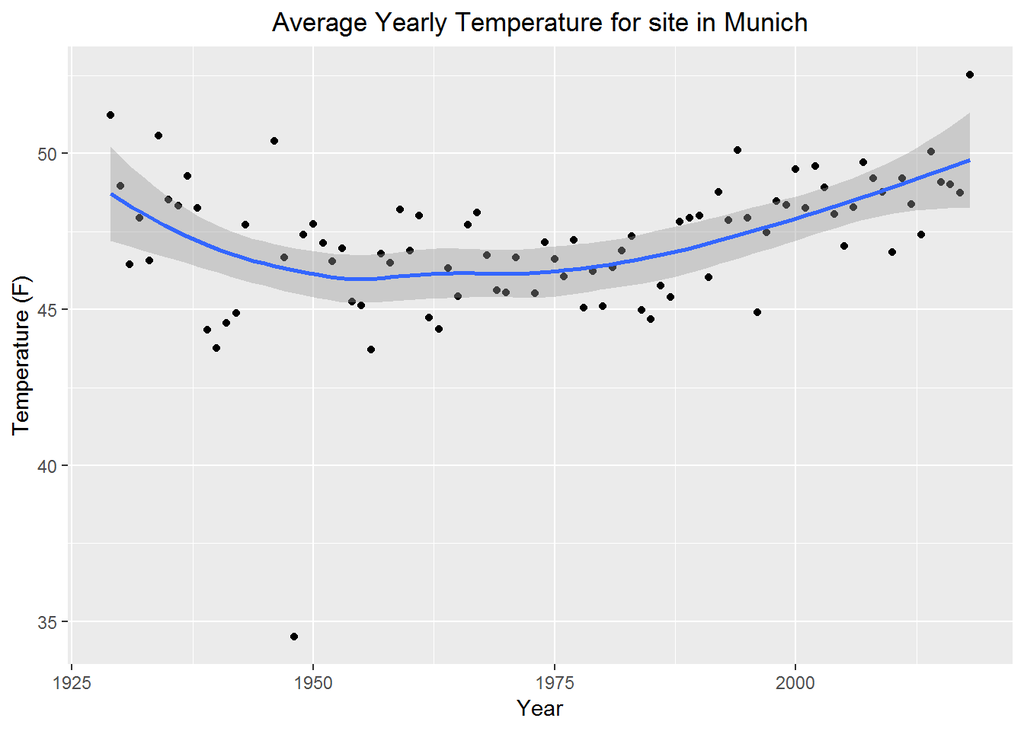

```r
# clean data from csv import
Site_data_clean <- Site_data_raw[1:14]
names(Site_data_clean) <- as.character(unlist(Site_data_clean[1,]))
Site_data_clean <- Site_data_clean[-1,]
indx <- sapply(Site_data_clean, is.factor)
indx[1]<-FALSE
Site_data_clean[indx] <- lapply(Site_data_clean[indx], function(x) as.numeric(as.character(x)))
Site_data_clean$YR_Avg <- rowMeans(Site_data_clean[3:14],na.rm = T)

# 108660-99999 is MUNCHEN from the ISD history doc
ggplot(
  data = Site_data_clean,
  aes(x=Year,y=YR_Avg)
)+geom_point()+ggtitle("Average Yearly Temperature for site in Munich")+labs(y="Temperature (F)", x = "Year")+theme(plot.title = element_text(hjust = 0.5))+geom_smooth(formula = 'y ~ x',method = 'loess')
```

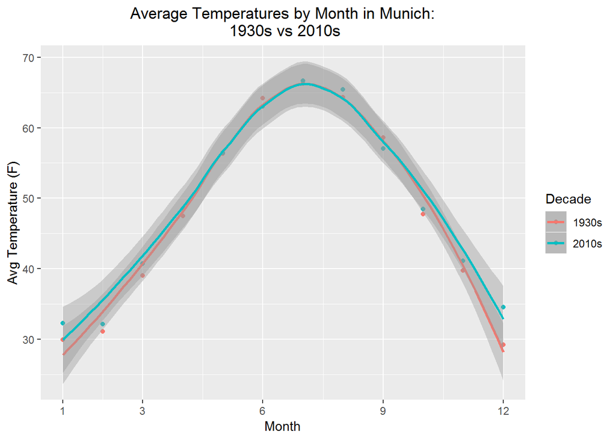

```r
year_1930_data <- Site_data_clean%>% filter((Year>=1930)& (Year<=1940)) %>%select(-YR_Avg,-Weather_site)
year_2010_data <- Site_data_clean%>% filter((Year>=2010)) %>%select(-YR_Avg,-Weather_site)

# make data long, get month averages for decade and take month abbreviations and make numbers for plotting
year_1930_data_long <- year_1930_data %>% rbind(c(1,colMeans(year_1930_data[2:13],na.rm = T))) %>% filter(Year==1) %>% gather(key="Month",value = "Avg_Temp",Jan:Dec) %>%mutate(Month_Num = match(Month,month.abb))
year_2010_data_long <- year_2010_data %>% rbind(c(1,colMeans(year_2010_data[2:13],na.rm = T))) %>% filter(Year==1)%>% gather(key="Month",value = "Avg_Temp",Jan:Dec)%>%mutate(Month_Num = match(Month,month.abb))

##Graphics

#start with points
points_years = ggplot()+ geom_point(data = year_1930_data_long,aes(x =Month_Num,y = Avg_Temp,color = "1930s"))+
  geom_point(data = year_2010_data_long,aes(x =Month_Num,y = Avg_Temp,color = "2010s"))

#add lines
lines_years = points_years + geom_smooth(data = year_1930_data_long,formula = 'y ~ x',method = 'loess',aes(x =Month_Num,y = Avg_Temp,color = "1930s"))+
  geom_smooth(data = year_2010_data_long,formula = 'y ~ x',method = 'loess',aes(x =Month_Num,y = Avg_Temp,color = "2010s"))

#add labels and theme changes
lines_years +
  labs(x = "Month" ,y="Avg Temperature (F)",color='Decade') +
  scale_x_continuous(breaks = c(1,3,6,9,12))+
  ggtitle("Average Temperatures by Month in Munich:\n 1930s vs 2010s")+
  theme(plot.title = element_text(hjust = 0.5))
```

This shows that between the first decade recorded and the last decade recorded the winters (early and late months) have gotten warmer but the summers (middle months) have stayed about the same in Munich

This will explore the data in weather_station_counts.csv and use the isd-history.csv file to match the names/country to the site count

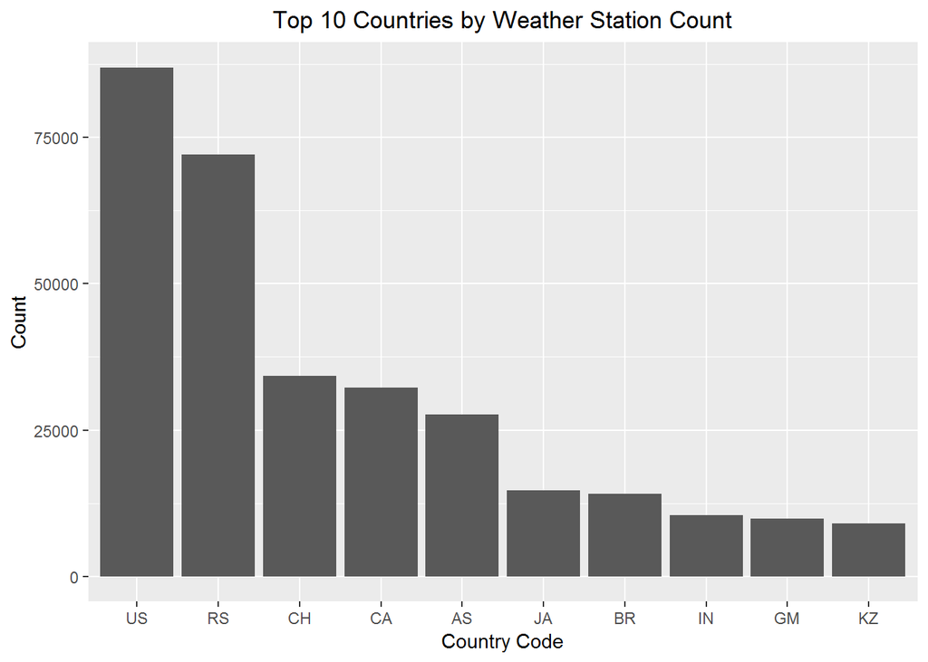

```r
Country_summary <- ISD_site_information %>% group_by(CTRY)%>%summarize(ctry_count = sum(Count))%>% arrange(desc(ctry_count))
ggplot()+geom_col(data = Country_summary[1:10,],aes(x = reorder(CTRY, -ctry_count),y = ctry_count))+ggtitle("Top 10 Countries by Weather Station Count")+theme(plot.title = element_text(hjust = 0.5))+labs(x = "Country Code",y = "Count")
```

Plot all sites by their LAT/LON on the world map

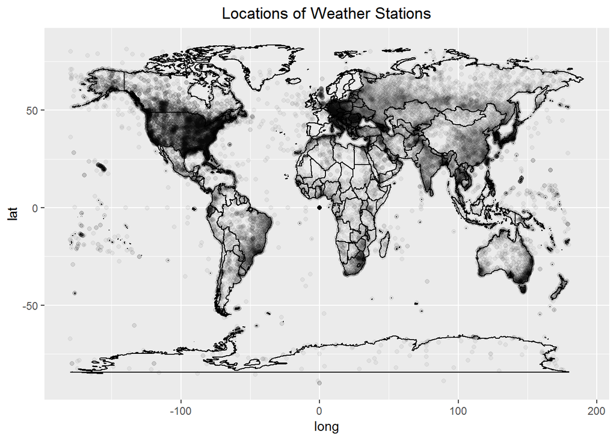

```r
world_map_df <- map_data("world")
ggplot() +
  geom_polygon(data = world_map_df, aes(x=long, y = lat, group = group), fill = NA, color = "black") + geom_point(data = ISD_site_information, aes(x = LON,y = LAT),alpha = .05)+ggtitle("Locations of Weather Stations")+theme(plot.title = element_text(hjust = 0.5))
```

As this shows the density of the sites are highest in the US, Europe and Japan.